# Actividad 2

Chávez Bartolo Julieta Janeth

05/01/2022

```r
library(datasets)
```

```r
exodatos<- read.csv(unz("./Datos/Exo.zip","Planetary_systems.csv"), header=T, skip=290)
attach(exodatos)
# Seleccionamos algunas de las columnas

library(dplyr)
exodatos<- select(exodatos, pl_name, discoverymethod,
                 sy_pnum, pl_masse, pl_eqt)   # library(dplyr)
names(exodatos)
```

```
## [1] "pl_name"         "discoverymethod" "sy_pnum"         "pl_masse"
## [5] "pl_eqt"
```

```r
# Opciones globales en graficas
par(mar=c(5.1,5,4.1,2.1),font=3,family="sans",bg="yellow")
```

### a) [5 puntos] Determina cual es el tipo de variable y su escala de medi-

ción.

Masa es un tipo de variable cuantitativa continua y su escala de medición es de razón. R la registra como una variaple tipo numérica.

### b) [15 puntos] De acuerdo al tipo de variable, aplica las herramientas

de análisis exploratorio (medidas de resumen, de tendencia central, dispersión y gráficas) e interpreta los resultados.

```r
tail(exodatos)    # ver los ultimos 6 renglones del conjunto de datos
```

```
##         pl_name discoverymethod sy_pnum pl_masse pl_eqt
## 29917 ups And d Radial Velocity       3       NA     NA
## 29918 ups And d Radial Velocity       3       NA     NA
## 29919 ups And d Radial Velocity       3       NA     NA
## 29920 ups And d Radial Velocity       3 3257.741     NA
## 29921  xi Aql b Radial Velocity       1       NA     NA
## 29922  xi Aql b Radial Velocity       1       NA     NA
```

Notemos que la variable pl_masse cuenta con NA’s de modo que habrá que limpiarlas.

```r
#Exploremos pl_mase
attach(exodatos) # con el attach ya puedo accesar a los nombres de las variables
```

Cambiemos el nombre de la variable “pl_masse” a “masa”.

```r
#        NUEVO                 # ANTERIOR
exom<- rename(exodatos, masa       = pl_masse)

names(exom)
```

```
## [1] "pl_name"         "discoverymethod" "sy_pnum"         "masa"
## [5] "pl_eqt"
```

```r
attach(exom)
masa[3] #Imprimamos el renglon 3 de la variable masa
```

```
## [1] NA
```

```r
head(exom)
```

```
##    pl_name discoverymethod sy_pnum masa pl_eqt
## 1 11 Com b Radial Velocity       1   NA     NA
## 2 11 Com b Radial Velocity       1   NA     NA
## 3 11 UMi b Radial Velocity       1   NA     NA
## 4 11 UMi b Radial Velocity       1   NA     NA
## 5 11 UMi b Radial Velocity       1   NA     NA
## 6 14 And b Radial Velocity       1   NA     NA
```

A simple vista notamos que existen planetas repetidos, para eliminar el sesgo en planetas con pocas repeticiones, nos quedaremos unicamente con un planeta de cada uno.

```r
exom2 <- exom %>% group_by(pl_name) %>%   # %>% operador pipe
  filter (! duplicated(pl_name))       # library(dplyr)

head(exom2)
```

```
## # A tibble: 6 × 5
## # Groups:   pl_name [6]
##   pl_name    discoverymethod sy_pnum  masa pl_eqt
##   <chr>      <chr>             <int> <dbl>  <int>
## 1 11 Com b   Radial Velocity       1    NA     NA
## 2 11 UMi b   Radial Velocity       1    NA     NA
## 3 14 And b   Radial Velocity       1    NA     NA
## 4 14 Her b   Radial Velocity       2    NA     NA
## 5 16 Cyg B b Radial Velocity       1    NA     NA
## 6 18 Del b   Radial Velocity       1    NA     NA
```

De modo que lo hemos solucionado.

```r
library("skimr")
skimr::skim(exom)
```

Data summary

| Name | exom |
| --- | --- |
| Number of rows | 29922 |
| Number of columns | 5 |
| _______________________ |  |
| Column type frequency: |  |
| character | 2 |
| numeric | 3 |
| ________________________ |  |
| Group variables | None |

**Variable type: character**

| skim_variable | n_missing | complete_rate | min | max | empty | n_unique | whitespace |
| --- | --- | --- | --- | --- | --- | --- | --- |
| pl_name | 0 | 1 | 5 | 29 | 0 | 4528 | 0 |
| discoverymethod | 0 | 1 | 7 | 29 | 0 | 11 | 0 |

**Variable type: numeric**

| skim_variable | n_missing | complete_rate | mean | sd | p0 | p25 | p50 | p75 | p100 | hist |
| --- | --- | --- | --- | --- | --- | --- | --- | --- | --- | --- |
| sy_pnum | 0 | 1.00 | 1.91 | 1.21 | 1.00 | 1.00 | 1.00 | 2.00 | 8.0 | ▇▂▁▁▁ |
| masa | 27278 | 0.09 | 579.35 | 1278.44 | 0.02 | 19.55 | 190.22 | 510.36 | 25426.4 | ▇▁▁▁▁ |
| pl_eqt | 16694 | 0.44 | 863.68 | 419.40 | 4.00 | 560.00 | 785.00 | 1073.00 | 4050.0 | ▇▆▁▁▁ |

Con esto nos cercioramos de que efectivamente la cantidad de datos faltantes es importante y no podríamos simplemente borrarlos en caso de ocupar otra variable pues nos quedaríamos unicamente con el 8.84% de los datos.

## Tabla de frecuencias, Análisis tabular y gráfico

```r
attach(exom2)
detach(exom)
detach(exodatos)

head((tabla_m <- table(masa)))  # tabla de frecuencias absolutas, imprimamos las primeras 5 pues son muchas
```

```
## masa
## 0.326  0.41  0.44 0.655 0.772 0.934
##     1     1     1     1     1     1
```

```r
head(tablar_m <- prop.table(tabla_m)) # tabla de frecuencias relativas
```

```
## masa
##      0.326       0.41       0.44      0.655      0.772      0.934
## 0.00128041 0.00128041 0.00128041 0.00128041 0.00128041 0.00128041
```

```r
library(fdth)
(tabla_contm<- fdt(na.omit(masa),breaks="FD",right=T))
```

```
##           Class limits   f   rf rf(%)  cf  cf(%)
##    (0.32274,137.71107] 271 0.35 34.70 271  34.70
##  (137.71107,275.09939] 151 0.19 19.33 422  54.03
##  (275.09939,412.48772]  85 0.11 10.88 507  64.92
##  (412.48772,549.87604]  36 0.05  4.61 543  69.53
##  (549.87604,687.26436]  44 0.06  5.63 587  75.16
##  (687.26436,824.65269]  31 0.04  3.97 618  79.13
##  (824.65269,962.04102]  25 0.03  3.20 643  82.33
##  (962.04102,1099.4293]  11 0.01  1.41 654  83.74
##  (1099.4293,1236.8177]   8 0.01  1.02 662  84.76
##   (1236.8177,1374.206]  14 0.02  1.79 676  86.56
##   (1374.206,1511.5943]   5 0.01  0.64 681  87.20
##  (1511.5943,1648.9826]   5 0.01  0.64 686  87.84
##   (1648.9826,1786.371]   3 0.00  0.38 689  88.22
##   (1786.371,1923.7593]   3 0.00  0.38 692  88.60
##  (1923.7593,2061.1476]   5 0.01  0.64 697  89.24
##  (2061.1476,2198.5359]   3 0.00  0.38 700  89.63
##  (2198.5359,2335.9243]   4 0.01  0.51 704  90.14
##  (2335.9243,2473.3126]   6 0.01  0.77 710  90.91
##  (2473.3126,2610.7009]   4 0.01  0.51 714  91.42
##  (2610.7009,2748.0892]   2 0.00  0.26 716  91.68
##  (2748.0892,2885.4776]   3 0.00  0.38 719  92.06
##  (2885.4776,3022.8659]   3 0.00  0.38 722  92.45
##  (3022.8659,3160.2542]   3 0.00  0.38 725  92.83
##  (3160.2542,3297.6425]   3 0.00  0.38 728  93.21
##  (3297.6425,3435.0309]   3 0.00  0.38 731  93.60
##  (3435.0309,3572.4192]   4 0.01  0.51 735  94.11
##  (3572.4192,3709.8075]   3 0.00  0.38 738  94.49
##  (3709.8075,3847.1958]   1 0.00  0.13 739  94.62
##  (3847.1958,3984.5842]   2 0.00  0.26 741  94.88
##  (3984.5842,4121.9725]   4 0.01  0.51 745  95.39
##  (4121.9725,4259.3608]   4 0.01  0.51 749  95.90
##  (4259.3608,4396.7491]   1 0.00  0.13 750  96.03
##  (4396.7491,4534.1375]   7 0.01  0.90 757  96.93
##  (4534.1375,4671.5258]   0 0.00  0.00 757  96.93
##  (4671.5258,4808.9141]   1 0.00  0.13 758  97.06
##  (4808.9141,4946.3024]   0 0.00  0.00 758  97.06
##  (4946.3024,5083.6908]   1 0.00  0.13 759  97.18
##  (5083.6908,5221.0791]   3 0.00  0.38 762  97.57
##  (5221.0791,5358.4674]   0 0.00  0.00 762  97.57
```

[output cut: 46 more lines]

```
##   (11678.33,11815.719]   0 0.00  0.00 780  99.87
##  (11815.719,11953.107]   0 0.00  0.00 780  99.87
##  (11953.107,12090.495]   0 0.00  0.00 780  99.87
##  (12090.495,12227.884]   0 0.00  0.00 780  99.87
##  (12227.884,12365.272]   0 0.00  0.00 780  99.87
##   (12365.272,12502.66]   0 0.00  0.00 780  99.87
##   (12502.66,12640.049]   0 0.00  0.00 780  99.87
##  (12640.049,12777.437]   0 0.00  0.00 780  99.87
##  (12777.437,12914.825]   0 0.00  0.00 780  99.87
##  (12914.825,13052.214]   0 0.00  0.00 780  99.87
##  (13052.214,13189.602]   0 0.00  0.00 780  99.87
##   (13189.602,13326.99]   0 0.00  0.00 780  99.87
##   (13326.99,13464.379]   0 0.00  0.00 780  99.87
##  (13464.379,13601.767]   0 0.00  0.00 780  99.87
##  (13601.767,13739.155]   1 0.00  0.13 781 100.00
```

Obtengamos el rango para segmentar el histograma

```r
range(na.omit(masa))
```

```
## [1]     0.326 13603.124
```

El histograma muestra el perfil de la distribución de probabilidad que mejor describe a la variable.

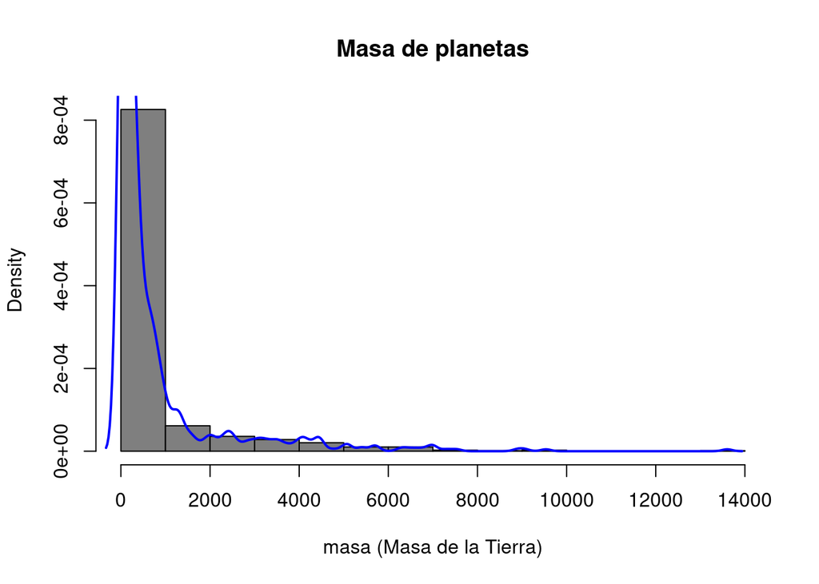

```r
hist(na.omit(masa),probability=T,col="grey50",
     main="Masa de planetas",
     xlab="masa (Masa de la Tierra)")  # histograma cuyo eje vertical esta en escala
# de "probabilidades".

lines(density(na.omit(masa)),lwd=2,col="blue")   # curva de densidad de probabilidad
```

Y acá observamos el histograma cuyo eje y representa la frecuencia absoluta.

```r
library(UsingR)
```

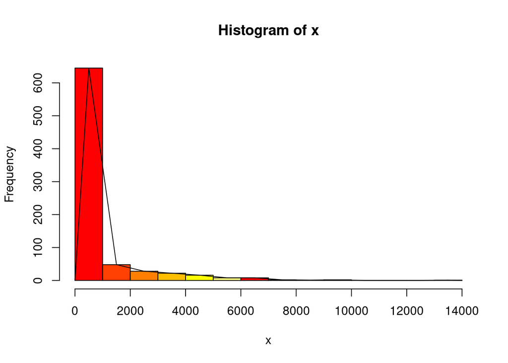

```r
simple.freqpoly(na.omit(masa),col=heat.colors(6))
```

Aprovechando la tabla de frecuencias con intervalos de clase y su histograma, vale la pena revisar la siguiente gráfica: ojiva

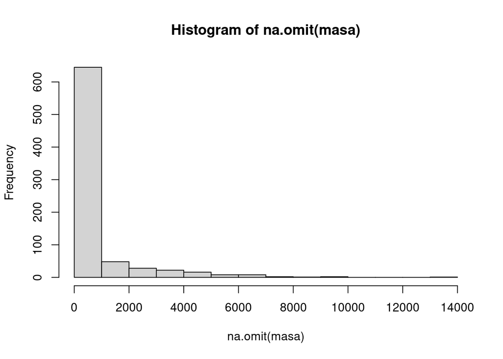

```r
library(agricolae)

hist_masa<- hist(na.omit(masa))
```

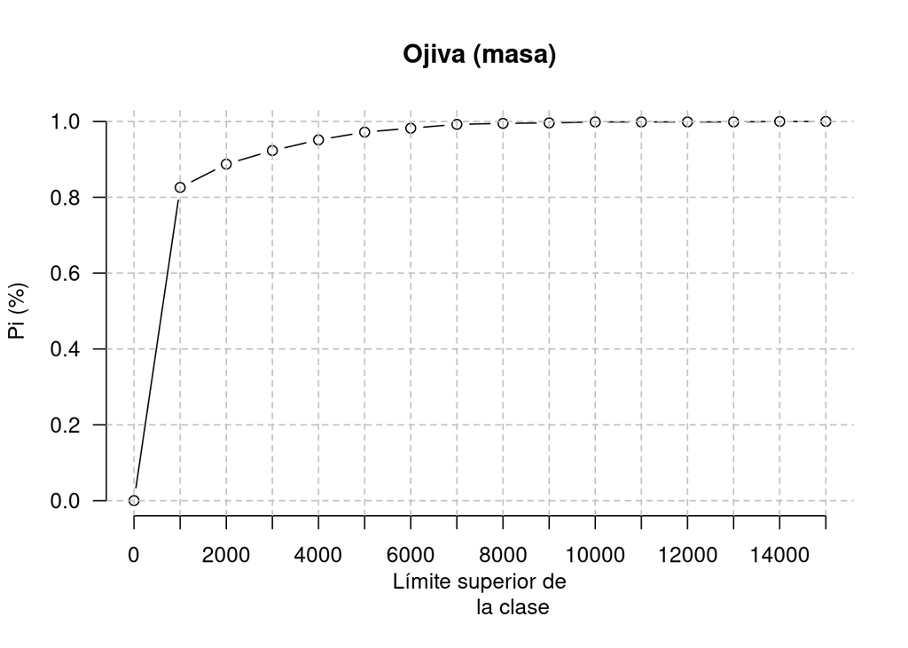

```
##    Límite superior de\n           la clase    RCF
## 1                                        0 0.0000
## 2                                     1000 0.8259
## 3                                     2000 0.8873
## 4                                     3000 0.9232
## 5                                     4000 0.9513
## 6                                     5000 0.9718
## 7                                     6000 0.9821
## 8                                     7000 0.9923
## 9                                     8000 0.9949
## 10                                    9000 0.9962
## 11                                   10000 0.9987
## 12                                   11000 0.9987
## 13                                   12000 0.9987
## 14                                   13000 0.9987
## 15                                   14000 1.0000
## 16                                   15000 1.0000
```

```r
ogive.freq(hist_masa,main="Ojiva (masa)",xlab="Límite superior de
           la clase",ylab="Pi (%)")
```

Veamos otras gráficas que ytambién se pueden hacer en el caso discreto. Por ejemplo la gráfica de puntos.

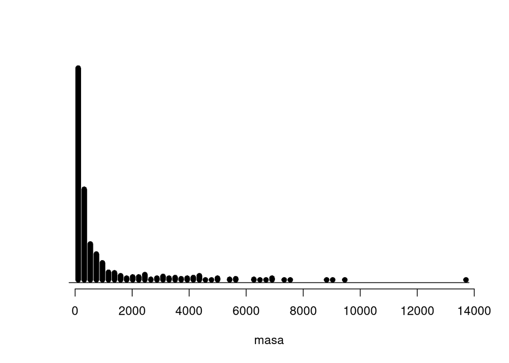

```r
library(BHH2)
dotPlot(masa,pch=16,col=10)   # libreria(BHH2)
```

O el diagrama de tallo y hojas.

```r
stem(masa)   # tallo-hojas
```

```
##
##   The decimal point is 3 digit(s) to the right of the |
##
##    0 | 00000000000000000000000000000000000000000000000000000000000000000000+560
##    1 | 0000000000011111122222233333333333344445555666778899
##    2 | 0000011223334444445555778999
##    3 | 00111223333555567789
##    4 | 000111113344444458
##    5 | 011144777
##    6 | 34578
##    7 | 00035
##    8 | 9
##    9 | 15
##   10 |
##   11 |
##   12 |
##   13 | 6
```

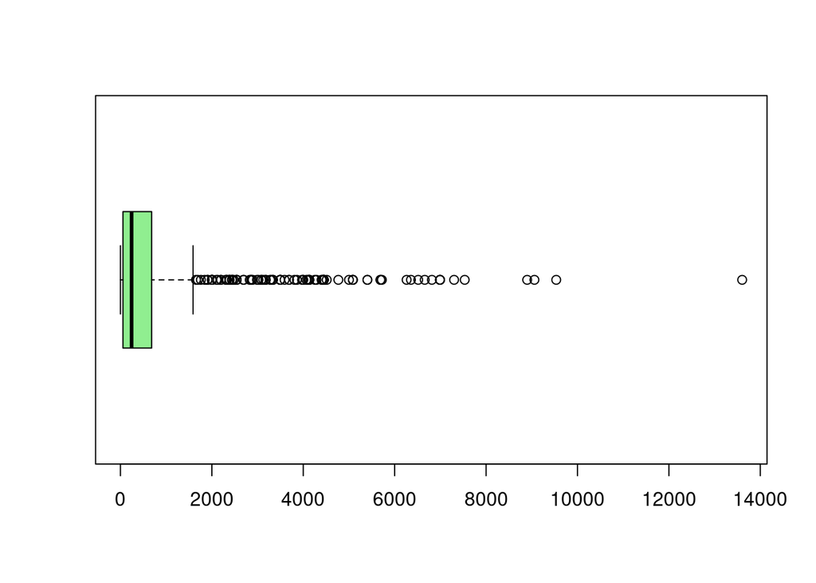

```r
boxplot(masa,horizontal = T,col="lightgreen")
boxplot(na.omit(masa),horizontal = T,col="lightgreen") # no afectan NA's
```

Vemos con el gráfico de cajas que existen muchos datos atípicos a la derecha. ### Medidas descriptivas “La moda”

```r
library(fdth)
mfv(na.omit(masa))
```

```
## [1] 266.9772
```

¿Tiene sentido para una variable continua?

Nótese que si las observaciones se redondean es posible que encontremos un valor que se repita varias veces. El programa R lo que hace es redondear hacia abajo (floor) y con ello localiza la moda. Esto no es adecuado.

Respuesta: usamos su tabla de frecuencias Habiamos visto que

```r
head(tabla_contm)  # para seleccionar una parte de los datos   # tabla de frecuencias para datos agrupados por intervalos de clase
```

```
## $table
##              Class limits   f          rf      rf(%)  cf     cf(%)
## 1     (0.32274,137.71107] 271 0.346991037 34.6991037 271  34.69910
## 2   (137.71107,275.09939] 151 0.193341869 19.3341869 422  54.03329
## 3   (275.09939,412.48772]  85 0.108834827 10.8834827 507  64.91677
## 4   (412.48772,549.87604]  36 0.046094750  4.6094750 543  69.52625
## 5   (549.87604,687.26436]  44 0.056338028  5.6338028 587  75.16005
## 6   (687.26436,824.65269]  31 0.039692702  3.9692702 618  79.12932
## 7   (824.65269,962.04102]  25 0.032010243  3.2010243 643  82.33035
## 8   (962.04102,1099.4293]  11 0.014084507  1.4084507 654  83.73880
## 9   (1099.4293,1236.8177]   8 0.010243278  1.0243278 662  84.76312
## 10   (1236.8177,1374.206]  14 0.017925736  1.7925736 676  86.55570
## 11   (1374.206,1511.5943]   5 0.006402049  0.6402049 681  87.19590
## 12  (1511.5943,1648.9826]   5 0.006402049  0.6402049 686  87.83611
## 13   (1648.9826,1786.371]   3 0.003841229  0.3841229 689  88.22023
```

[output cut: 91 more lines]

```r
str(tabla_contm)    # para ver como debemos llamar a cada elemento
```

```
## List of 2
##  $ table :'data.frame':  100 obs. of  6 variables:
##   ..$ Class limits: Factor w/ 100 levels "(0.32274,137.71107]",..: 1 2 3 4 5 6 7 8 9 10 ...
##   ..$ f           : int [1:100] 271 151 85 36 44 31 25 11 8 14 ...
##   ..$ rf          : num [1:100] 0.347 0.1933 0.1088 0.0461 0.0563 ...
##   ..$ rf(%)       : num [1:100] 34.7 19.33 10.88 4.61 5.63 ...
##   ..$ cf          : num [1:100] 271 422 507 543 587 618 643 654 662 676 ...
##   ..$ cf(%)       : num [1:100] 34.7 54 64.9 69.5 75.2 ...
##  $ breaks: Named num [1:4] 3.23e-01 1.37e+04 1.37e+02 1.00
##   ..- attr(*, "names")= chr [1:4] "start" "end" "h" "right"
##  - attr(*, "class")= chr [1:3] "fdt.default" "fdt" "list"
```

Indica el renglon cuya frecuencia absoluta, f, es maxima

```r
which.max(tabla_contm$table$f)  # indica el renglon cuya frecuencia absoluta, f, es maxima
```

```
## [1] 1
```

Lo cual es ecidente en los histogramas, se puede concluir que la mayoría de los planetas, siendo especificos el 34.7% de los planetas tienen masas en el intervalor (0.32274,137.71107]) más cercano al de la tierra.

```r
tabla_contm$table$`Class limits`[which.max(tabla_contm$table$f)] # indica la CLASE MODAL
```

```
## [1] (0.32274,137.71107]
## 100 Levels: (0.32274,137.71107] (137.71107,275.09939] ... (13601.767,13739.155]
```

Comparamos los resultados (sin agrupar y agrupados) y claramente son ¡MUY DISTINTOS!

Media:

```r
mean(na.omit(masa)); mean(masa, na.rm=T)
```

```
## [1] 758.1962
```

```
## [1] 758.1962
```

Cuantiles y Amplitud intercuartílica’

```r
quantile(na.omit(masa), probs = c(0.25,0.50,0.75))
```

```
##       25%       50%       75%
##  54.98459 244.09344 682.35200
```

Varianza y desviación estándar

```r
var(na.omit(masa)); sd(na.omit(masa))
```

```
## [1] 2056873
```

```
## [1] 1434.18
```

```r
mean(abs(na.omit(masa)-mean(na.omit(masa))))   # error medio (media)
```

```
## [1] 851.7295
```

```r
mean(abs(na.omit(masa)-median(na.omit(masa))))  # error medio (mediana)
```

```
## [1] 674.5387
```

```r
mean(abs(na.omit(masa)-mfv(na.omit(masa))))  # error medio (moda) OJO!!!
```

```
## [1] 675.0379
```

Coeficiente de variación

```r
c.v<- sd(masa,na.rm=T)/mean(masa, na.rm=T); c.v
```

```
## [1] 1.891569
```

#### Asimetría y curtosis

```
Coeficiente de asimetría
```

```r
(j3<- moments::skewness(masa,na.rm=T))
```

```
## [1] 3.583111
```

kurtosis

```r
(j4<- moments::kurtosis(masa,na.rm=T))
```

```
## [1] 19.59066
```

Siendo entonces una distribución más bien Leptokurtica o angosta.

```r
fivenum(na.omit(masa)) # minimum, lower-hinge, median, upper-hinge, maximum)
```

```
## [1]     0.32600    54.98459   244.09344   682.35200 13603.12400
```

```r
summary(masa)
```

```
##      Min.   1st Qu.    Median      Mean   3rd Qu.      Max.      NA's
##     0.326    54.985   244.093   758.196   682.352 13603.124      3747
```

# c) [5 puntos]

Divide el rango de masas en 4 y utilízalo como límite para segmentar la variable en cuatro diferentes categorías, ordenadas por tamaño: chico, mediano, grande, súper. ¿Qué tipo de variable es ahora?, ¿cuántos planetas hay en cada categoría?

Veamos de nuevo el rango de la masa de los planetas

```r
range(na.omit(masa))
```

```
## [1]     0.326 13603.124
```

Habremos de dividirlo en 4.Yo lo haré como sigue:

[output not shown]

```r
TipoPlaneta <- NA
TipoPlaneta[masa >= 0 & masa <= 3400] <- "Chico"
TipoPlaneta[masa > 3400 & masa <= 6800] <- "Mediano"
TipoPlaneta[masa > 6800 & masa <= 10200] <- "Grande"
TipoPlaneta[masa > 10200 & masa <= 13604] <- "Súper"
TipoPlaneta
```

```
##    [1] NA        NA        NA        NA        NA        NA        "Chico"
##    [8] NA        NA        NA        "Mediano" NA        "Mediano" "Chico"
##   [15] "Chico"   "Chico"   "Mediano" "Mediano" NA        NA        NA
##   [22] NA        NA        NA        NA        NA        NA        "Chico"
##   [29] NA        NA        "Chico"   NA        NA        NA        NA
##   [36] NA        NA        NA        NA        NA        NA        NA
##   [43] "Mediano" "Chico"   "Chico"   NA        NA        NA        NA
##   [50] NA        NA        NA        "Chico"   NA        NA        NA
##   [57] NA        NA        NA        NA        NA        NA        NA
##   [64] NA        NA        NA        NA        NA        NA        "Chico"
##   [71] "Chico"   "Mediano" "Mediano" "Chico"   "Mediano" "Chico"   "Chico"
##   [78] "Chico"   "Chico"   "Chico"   "Chico"   "Chico"   "Chico"   "Chico"
##   [85] "Chico"   "Chico"   "Chico"   NA        "Chico"   "Chico"   "Chico"
##   [92] "Chico"   "Chico"   "Chico"   "Chico"   "Chico"   "Chico"   "Chico"
##   [99] "Grande"  "Chico"   "Chico"   "Chico"   "Chico"   "Chico"   "Chico"
```

[output cut: 632 more lines]

Quitemos los NAś

```r
TipoPlaneta <- na.omit(TipoPlaneta)
TipoPlaneta
```

```
##   [1] "Chico"   "Mediano" "Mediano" "Chico"   "Chico"   "Chico"   "Mediano"
##   [8] "Mediano" "Chico"   "Chico"   "Mediano" "Chico"   "Chico"   "Chico"
##  [15] "Chico"   "Chico"   "Mediano" "Mediano" "Chico"   "Mediano" "Chico"
##  [22] "Chico"   "Chico"   "Chico"   "Chico"   "Chico"   "Chico"   "Chico"
##  [29] "Chico"   "Chico"   "Chico"   "Chico"   "Chico"   "Chico"   "Chico"
##  [36] "Chico"   "Chico"   "Chico"   "Chico"   "Chico"   "Chico"   "Chico"
##  [43] "Grande"  "Chico"   "Chico"   "Chico"   "Chico"   "Chico"   "Chico"
##  [50] "Chico"   "Chico"   "Chico"   "Chico"   "Grande"  "Mediano" "Chico"
##  [57] "Chico"   "Chico"   "Chico"   "Mediano" "Chico"   "Chico"   "Chico"
##  [64] "Mediano" "Chico"   "Chico"   "Chico"   "Chico"   "Chico"   "Chico"
##  [71] "Chico"   "Chico"   "Chico"   "Chico"   "Chico"   "Mediano" "Mediano"
##  [78] "Mediano" "Mediano" "Chico"   "Chico"   "Chico"   "Chico"   "Chico"
##  [85] "Chico"   "Chico"   "Chico"   "Chico"   "Chico"   "Chico"   "Chico"
##  [92] "Chico"   "Chico"   "Chico"   "Chico"   "Chico"   "Chico"   "Chico"
##  [99] "Chico"   "Chico"   "Chico"   "Chico"   "Chico"   "Chico"   "Chico"
```

[output cut: 368 more lines]

```r
masa<-na.omit(masa)
masa
```

```
##   [1]  2543.00000  4131.79000  4417.83700  2383.60000  1589.15000   603.87700
##   [7]  6657.48000  3972.87500    54.47380    44.81200  4290.50000    17.00000
##  [13]    13.60000    16.30000  3337.10000  2479.06157  3994.48600  3686.82800
##  [19]  2002.31896  5403.00000   340.07810   874.00000   743.72220   277.46559
##  [25]   416.99296  2437.75610   170.03200   781.86180  1099.69180   367.09365
##  [31]  1052.01730  1366.66900   705.58260    12.20000   982.09470     5.70000
##  [37]    28.00000    93.12419   184.34140  3273.64900   153.82972   266.97720
##  [43]  6814.27520   921.70700   266.97720   232.33373   148.42000   940.74000
##  [49]     4.80000     8.40000    69.92000   266.97000    47.67450  9057.77000
##  [55]  3496.00000  1995.88832   413.17900     7.72000   953.49000  4131.79000
##  [61]     8.75000    14.67000    10.18000  5085.28000     1.62000   794.50000
##  [67]    13.90000     8.40000     2.82000  1271.30000  2129.46100     6.83000
##  [73]     3.42000     2.42000     2.35000  6261.21962  6356.00000  5000.00000
##  [79]  3591.30000    24.02795   731.00900   271.09800   721.79193   618.47100
##  [85]  1332.60500   184.34140    63.56600  2828.60000  2302.89900  1291.28900
```

[output cut: 387 more lines]

```r
library(dplyr)
# Ahora si ordenamos las columnas
datos<- cbind(masa,TipoPlaneta)


head(datos)
```

```
##      masa       TipoPlaneta
## [1,] "2543"     "Chico"
## [2,] "4131.79"  "Mediano"
## [3,] "4417.837" "Mediano"
## [4,] "2383.6"   "Chico"
## [5,] "1589.15"  "Chico"
## [6,] "603.877"  "Chico"
```

```r
library(naniar)
pct_miss(datos) #Datos faltantes
```

```
## [1] 0
```

Vemos que hay 0 datos faltantes.

### ¿Qué tipo de variable es ahora?

Ahora es una variable cualitativa y su escala de medición es Ordinal. R la identifica ahora como una variable categórica.

### ¿cuántos planetas hay en cada categoría?

La respuesta está en la tabla de frecuencias absolutas

```r
(tabla_tv <- table(TipoPlaneta))  # tabla de frecuencias absolutas
```

```
## TipoPlaneta
##   Chico  Grande Mediano   Súper
##     731       9      40       1
```

# d) [15 puntos]

Realiza el análisis exploratorio correspondiente de acuerdo al nuevo tipo de variable obtenida.

#### Análisis estadístico de las variables cualitativas

```r
(tablar_tv <- round(prop.table(tabla_tv),digits=2)) # tabla de frecuencias relativas
```

```
## TipoPlaneta
##   Chico  Grande Mediano   Súper
##    0.94    0.01    0.05    0.00
```

```r
levels(as.factor(TipoPlaneta))
```

```
## [1] "Chico"   "Grande"  "Mediano" "Súper"
```

Diagrama de barras

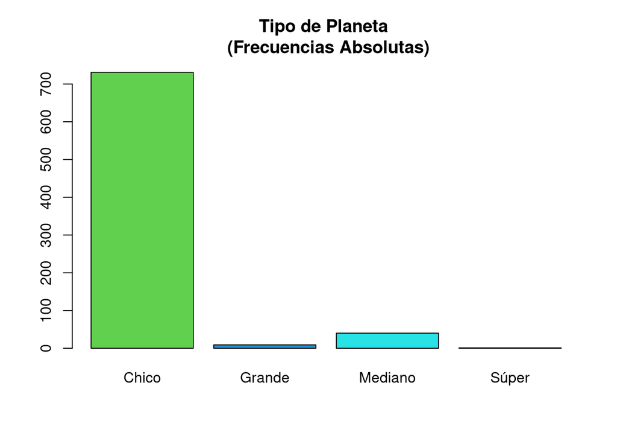

```r
barplot(tabla_tv,col=3:5)

title("Tipo de Planeta \n (Frecuencias Absolutas)")
```

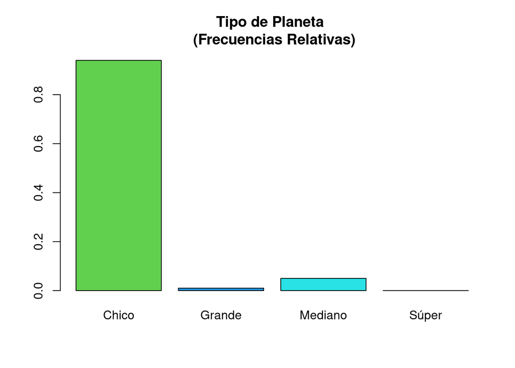

```r
barplot(tablar_tv,col=3:5)
title("Tipo de Planeta \n (Frecuencias Relativas)")
```

tienen sentido: moda y mediana (o cualquier porcentil)

Moda

```r
mfv(TipoPlaneta)
```

```
## [1] "Chico"
```

La mayoría de los planetas son de tamaño “Chico”.

```
Mediana (porcentiles en general)
```

Esta variable es ordinal por lo que tiene sentido utilizar esta medida de resumen, sin embargo no se podrá calcular a menos que las categorías tengan asignado un número.

```r
Tipo <- NA
Tipo[TipoPlaneta=="Chico"] <- 1
Tipo[TipoPlaneta=="Mediano"] <- 2
Tipo[TipoPlaneta=="Grande"] <- 3
Tipo[TipoPlaneta=="Súper"] <- 4


Tipo[1:10]   # primeros 10 datos
```

```
##  [1] 1 2 2 1 1 1 2 2 1 1
```

```r
median(Tipo); median(TipoPlaneta)
```

```
## [1] 1
```

```
## [1] "Chico"
```

```r
quantile(Tipo,prob=c(0.10,0.25,0.5,0.75))
```

```
## 10% 25% 50% 75%
##   1   1   1   1
```

# e) [10 puntos]

¿Cuáles son las principales diferencias al realizar el primer análisis y el segundo?, ¿se pueden hacer las mismas conclusiones?

El primer análisis es mucho más exacto, sin embargo para motivos ilustrativos el segundo análisis ha sido mucho más digerible de entender.

```r
masa
```

[output not shown]

[output cut: 387 more lines]